# Risk Factor Analysis

## Outcome Variable

**Outcome Variable:** haz

## Predictor Variables

**Intervention Variable:** exclfeed3

**Adjustment Set:**

unadjusted

## Stratifying Variables

The analysis was stratified on these variable(s):

- agecat
- studyid
- country

## Data Summary

| agecat | studyid | country | exclfeed3 | n_cell | n |
| --- | --- | --- | --- | --- | --- |
| Birth | ki0047075b-MAL-ED | BANGLADESH | 1 | 138 | 215 |
| Birth | ki0047075b-MAL-ED | BANGLADESH | 0 | 77 | 215 |
| Birth | ki0047075b-MAL-ED | BRAZIL | 1 | 12 | 57 |
| Birth | ki0047075b-MAL-ED | BRAZIL | 0 | 45 | 57 |
| Birth | ki0047075b-MAL-ED | INDIA | 1 | 24 | 41 |
| Birth | ki0047075b-MAL-ED | INDIA | 0 | 17 | 41 |
| Birth | ki0047075b-MAL-ED | NEPAL | 1 | 8 | 26 |
| Birth | ki0047075b-MAL-ED | NEPAL | 0 | 18 | 26 |
| Birth | ki0047075b-MAL-ED | PERU | 1 | 49 | 223 |
| Birth | ki0047075b-MAL-ED | PERU | 0 | 174 | 223 |
| Birth | ki0047075b-MAL-ED | SOUTH AFRICA | 1 | 12 | 100 |
| Birth | ki0047075b-MAL-ED | SOUTH AFRICA | 0 | 88 | 100 |
| Birth | ki0047075b-MAL-ED | TANZANIA, UNITED REPUBLIC OF | 1 | 17 | 102 |
| Birth | ki0047075b-MAL-ED | TANZANIA, UNITED REPUBLIC OF | 0 | 85 | 102 |
| Birth | ki1000108-CMC-V-BCS-2002 | INDIA | 1 | 4 | 4 |
| Birth | ki1000108-CMC-V-BCS-2002 | INDIA | 0 | 0 | 4 |
| Birth | ki1000108-IRC | INDIA | 1 | 0 | 10 |
| Birth | ki1000108-IRC | INDIA | 0 | 10 | 10 |
| Birth | ki1000109-EE | PAKISTAN | 1 | 35 | 35 |
| Birth | ki1000109-EE | PAKISTAN | 0 | 0 | 35 |
| Birth | ki1000304b-SAS-CompFeed | INDIA | 1 | 346 | 364 |
| Birth | ki1000304b-SAS-CompFeed | INDIA | 0 | 18 | 364 |
| Birth | ki1017093b-PROVIDE | BANGLADESH | 1 | 387 | 539 |
| Birth | ki1017093b-PROVIDE | BANGLADESH | 0 | 152 | 539 |
| Birth | ki1101329-Keneba | GAMBIA | 1 | 1198 | 1356 |
| Birth | ki1101329-Keneba | GAMBIA | 0 | 158 | 1356 |
| Birth | ki1113344-GMS-Nepal | NEPAL | 1 | 380 | 458 |
| Birth | ki1113344-GMS-Nepal | NEPAL | 0 | 78 | 458 |
| Birth | kiGH5241-JiVitA-3 | BANGLADESH | 1 | 12014 | 13276 |
| Birth | kiGH5241-JiVitA-3 | BANGLADESH | 0 | 1262 | 13276 |

[output cut: 64 more lines]

The following strata were considered:

- agecat: 24 months, studyid: ki0047075b-MAL-ED, country: BANGLADESH
- agecat: 24 months, studyid: ki0047075b-MAL-ED, country: BRAZIL
- agecat: 24 months, studyid: ki0047075b-MAL-ED, country: INDIA
- agecat: 24 months, studyid: ki0047075b-MAL-ED, country: NEPAL
- agecat: 24 months, studyid: ki0047075b-MAL-ED, country: PERU
- agecat: 24 months, studyid: ki0047075b-MAL-ED, country: SOUTH AFRICA
- agecat: 24 months, studyid: ki0047075b-MAL-ED, country: TANZANIA, UNITED REPUBLIC OF
- agecat: 24 months, studyid: ki1000108-CMC-V-BCS-2002, country: INDIA
- agecat: 24 months, studyid: ki1000108-IRC, country: INDIA
- agecat: 24 months, studyid: ki1000109-EE, country: PAKISTAN
- agecat: 24 months, studyid: ki1017093b-PROVIDE, country: BANGLADESH
- agecat: 24 months, studyid: ki1101329-Keneba, country: GAMBIA
- agecat: 24 months, studyid: ki1113344-GMS-Nepal, country: NEPAL
- agecat: 24 months, studyid: kiGH5241-JiVitA-3, country: BANGLADESH
- agecat: 24 months, studyid: kiGH5241-JiVitA-4, country: BANGLADESH
- agecat: 6 months, studyid: ki0047075b-MAL-ED, country: BANGLADESH
- agecat: 6 months, studyid: ki0047075b-MAL-ED, country: BRAZIL
- agecat: 6 months, studyid: ki0047075b-MAL-ED, country: INDIA
- agecat: 6 months, studyid: ki0047075b-MAL-ED, country: NEPAL
- agecat: 6 months, studyid: ki0047075b-MAL-ED, country: PERU
- agecat: 6 months, studyid: ki0047075b-MAL-ED, country: SOUTH AFRICA
- agecat: 6 months, studyid: ki0047075b-MAL-ED, country: TANZANIA, UNITED REPUBLIC OF
- agecat: 6 months, studyid: ki1000108-CMC-V-BCS-2002, country: INDIA
- agecat: 6 months, studyid: ki1000108-IRC, country: INDIA
- agecat: 6 months, studyid: ki1000109-EE, country: PAKISTAN
- agecat: 6 months, studyid: ki1000304b-SAS-CompFeed, country: INDIA
- agecat: 6 months, studyid: ki1017093b-PROVIDE, country: BANGLADESH
- agecat: 6 months, studyid: ki1101329-Keneba, country: GAMBIA
- agecat: 6 months, studyid: ki1113344-GMS-Nepal, country: NEPAL
- agecat: 6 months, studyid: kiGH5241-JiVitA-3, country: BANGLADESH
- agecat: 6 months, studyid: kiGH5241-JiVitA-4, country: BANGLADESH
- agecat: Birth, studyid: ki0047075b-MAL-ED, country: BANGLADESH
- agecat: Birth, studyid: ki0047075b-MAL-ED, country: BRAZIL
- agecat: Birth, studyid: ki0047075b-MAL-ED, country: INDIA
- agecat: Birth, studyid: ki0047075b-MAL-ED, country: NEPAL
- agecat: Birth, studyid: ki0047075b-MAL-ED, country: PERU
- agecat: Birth, studyid: ki0047075b-MAL-ED, country: SOUTH AFRICA
- agecat: Birth, studyid: ki0047075b-MAL-ED, country: TANZANIA, UNITED REPUBLIC OF
- agecat: Birth, studyid: ki1000108-CMC-V-BCS-2002, country: INDIA
- agecat: Birth, studyid: ki1000108-IRC, country: INDIA
- agecat: Birth, studyid: ki1000109-EE, country: PAKISTAN
- agecat: Birth, studyid: ki1000304b-SAS-CompFeed, country: INDIA
- agecat: Birth, studyid: ki1017093b-PROVIDE, country: BANGLADESH
- agecat: Birth, studyid: ki1101329-Keneba, country: GAMBIA
- agecat: Birth, studyid: ki1113344-GMS-Nepal, country: NEPAL
- agecat: Birth, studyid: kiGH5241-JiVitA-3, country: BANGLADESH
- agecat: Birth, studyid: kiGH5241-JiVitA-4, country: BANGLADESH

### Dropped Strata

Some strata were dropped due to rare outcomes:

- agecat: Birth, studyid: ki1000108-CMC-V-BCS-2002, country: INDIA
- agecat: Birth, studyid: ki1000108-IRC, country: INDIA
- agecat: Birth, studyid: ki1000109-EE, country: PAKISTAN
- agecat: 6 months, studyid: ki1000108-CMC-V-BCS-2002, country: INDIA
- agecat: 6 months, studyid: ki1000108-IRC, country: INDIA
- agecat: 6 months, studyid: ki1000109-EE, country: PAKISTAN
- agecat: 24 months, studyid: ki1000108-CMC-V-BCS-2002, country: INDIA
- agecat: 24 months, studyid: ki1000108-IRC, country: INDIA
- agecat: 24 months, studyid: ki1000109-EE, country: PAKISTAN

## Methods Detail

We’re interested in the causal parameters $E[Y_a]$ for all values of $a \in \mathcal{A}$. These parameters represent the mean outcome if, possibly contrary to fact, we intervened to set all units to have $A=a$. Under the randomization and positivity assumptions, these are identified by the statistical parameters $\psi_a=E_W[E_{Y|A,W}(Y|A=a,W)]$. In addition, we’re interested in the mean of $Y$, $E[Y]$ under no intervention (the observed mean). We will estimate these parameters by using SuperLearner to fit the relevant likelihood factors – $E_{Y|A,W}(Y|A=a,W)$ and $p(A=a|W)$, and then updating our likelihood fit using a joint TMLE.

For unadjusted analyses ($W=\{\}$), initial likelihoods were estimated using Lrnr_glm to estimate the simple $E(Y|A)$ and Lrnr_mean to estimate $p(A)$. For adjusted analyses, a small library containing Lrnr_glmnet, Lrnr_xgboost, and Lrnr_mean was used.

Having estimated these parameters, we will then use the delta method to estimate relative risks and attributable risks relative to a prespecified baseline level of $A$.

# Results Detail

## Results Plots

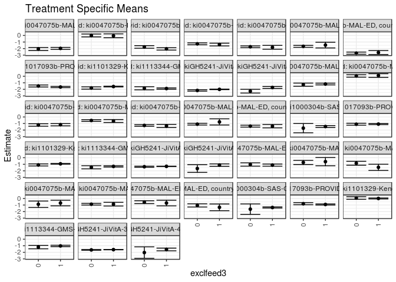

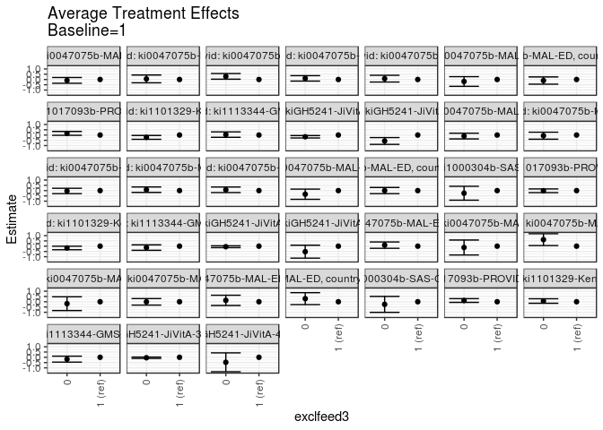

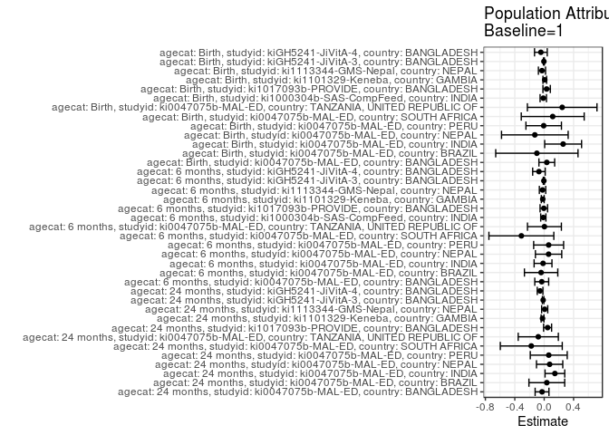

## Results Table

### Parameter: TSM

| agecat | studyid | country | intervention_level | baseline_level | estimate | ci_lower | ci_upper |
| --- | --- | --- | --- | --- | --- | --- | --- |
| Birth | ki0047075b-MAL-ED | BANGLADESH | 1 | NA | -1.1304348 | -1.2909464 | -0.9699232 |
| Birth | ki0047075b-MAL-ED | BANGLADESH | 0 | NA | -1.0314286 | -1.2830106 | -0.7798466 |
| Birth | ki0047075b-MAL-ED | BRAZIL | 1 | NA | -0.6000000 | -1.2327078 | 0.0327078 |
| Birth | ki0047075b-MAL-ED | BRAZIL | 0 | NA | -0.7262222 | -1.0462770 | -0.4061674 |
| Birth | ki0047075b-MAL-ED | INDIA | 1 | NA | -1.4654167 | -1.9400167 | -0.9908166 |
| Birth | ki0047075b-MAL-ED | INDIA | 0 | NA | -0.8435294 | -1.1419052 | -0.5451536 |
| Birth | ki0047075b-MAL-ED | NEPAL | 1 | NA | -0.6962500 | -1.1273498 | -0.2651502 |
| Birth | ki0047075b-MAL-ED | NEPAL | 0 | NA | -0.8800000 | -1.3706027 | -0.3893973 |
| Birth | ki0047075b-MAL-ED | PERU | 1 | NA | -0.8685714 | -1.1502206 | -0.5869222 |
| Birth | ki0047075b-MAL-ED | PERU | 0 | NA | -0.8772989 | -1.0058028 | -0.7487949 |
| Birth | ki0047075b-MAL-ED | SOUTH AFRICA | 1 | NA | -0.6958333 | -1.1306097 | -0.2610570 |
| Birth | ki0047075b-MAL-ED | SOUTH AFRICA | 0 | NA | -0.5638636 | -0.7820314 | -0.3456959 |
| Birth | ki0047075b-MAL-ED | TANZANIA, UNITED REPUBLIC OF | 1 | NA | -1.3535294 | -1.8653375 | -0.8417213 |
| Birth | ki0047075b-MAL-ED | TANZANIA, UNITED REPUBLIC OF | 0 | NA | -1.0596471 | -1.3047881 | -0.8145060 |
| Birth | ki1000304b-SAS-CompFeed | INDIA | 1 | NA | -1.3813295 | -1.4669649 | -1.2956940 |
| Birth | ki1000304b-SAS-CompFeed | INDIA | 0 | NA | -1.6316667 | -2.4310586 | -0.8322747 |
| Birth | ki1017093b-PROVIDE | BANGLADESH | 1 | NA | -0.9182171 | -1.0025662 | -0.8338679 |
| Birth | ki1017093b-PROVIDE | BANGLADESH | 0 | NA | -0.8007895 | -0.9570548 | -0.6445241 |
| Birth | ki1101329-Keneba | GAMBIA | 1 | NA | 0.0018781 | -0.0723763 | 0.0761325 |
| Birth | ki1101329-Keneba | GAMBIA | 0 | NA | 0.0701266 | -0.1295523 | 0.2698055 |
| Birth | ki1113344-GMS-Nepal | NEPAL | 1 | NA | -1.0255789 | -1.1325437 | -0.9186142 |
| Birth | ki1113344-GMS-Nepal | NEPAL | 0 | NA | -1.2014103 | -1.4639594 | -0.9388612 |
| Birth | kiGH5241-JiVitA-3 | BANGLADESH | 1 | NA | -1.5888697 | -1.6127659 | -1.5649734 |
| Birth | kiGH5241-JiVitA-3 | BANGLADESH | 0 | NA | -1.6306973 | -1.6945172 | -1.5668774 |
| Birth | kiGH5241-JiVitA-4 | BANGLADESH | 1 | NA | -1.5623810 | -1.7668126 | -1.3579493 |
| Birth | kiGH5241-JiVitA-4 | BANGLADESH | 0 | NA | -2.0363636 | -2.9086668 | -1.1640605 |
| 6 months | ki0047075b-MAL-ED | BANGLADESH | 1 | NA | -1.1907785 | -1.3236854 | -1.0578716 |
| 6 months | ki0047075b-MAL-ED | BANGLADESH | 0 | NA | -1.2871811 | -1.5237565 | -1.0506056 |
| 6 months | ki0047075b-MAL-ED | BRAZIL | 1 | NA | 0.1029167 | -0.1733737 | 0.3792070 |
| 6 months | ki0047075b-MAL-ED | BRAZIL | 0 | NA | 0.0410630 | -0.1467461 | 0.2288721 |
| 6 months | ki0047075b-MAL-ED | INDIA | 1 | NA | -1.1845000 | -1.3589674 | -1.0100326 |
| 6 months | ki0047075b-MAL-ED | INDIA | 0 | NA | -1.2175500 | -1.4034570 | -1.0316430 |
| 6 months | ki0047075b-MAL-ED | NEPAL | 1 | NA | -0.6231667 | -0.8470544 | -0.3992790 |
| 6 months | ki0047075b-MAL-ED | NEPAL | 0 | NA | -0.5367622 | -0.6669112 | -0.4066133 |
| 6 months | ki0047075b-MAL-ED | PERU | 1 | NA | -1.3714617 | -1.6053155 | -1.1376080 |
| 6 months | ki0047075b-MAL-ED | PERU | 0 | NA | -1.2931898 | -1.4138326 | -1.1725470 |
| 6 months | ki0047075b-MAL-ED | SOUTH AFRICA | 1 | NA | -0.7557576 | -1.2217874 | -0.2897278 |
| 6 months | ki0047075b-MAL-ED | SOUTH AFRICA | 0 | NA | -1.0969895 | -1.2319508 | -0.9620281 |
| 6 months | ki0047075b-MAL-ED | TANZANIA, UNITED REPUBLIC OF | 1 | NA | -1.4064855 | -1.6630657 | -1.1499053 |
| 6 months | ki0047075b-MAL-ED | TANZANIA, UNITED REPUBLIC OF | 0 | NA | -1.4020984 | -1.5467299 | -1.2574669 |
| 6 months | ki1000304b-SAS-CompFeed | INDIA | 1 | NA | -1.4578628 | -1.6049871 | -1.3107385 |
| 6 months | ki1000304b-SAS-CompFeed | INDIA | 0 | NA | -1.7063158 | -2.4149433 | -0.9976883 |
| 6 months | ki1017093b-PROVIDE | BANGLADESH | 1 | NA | -1.0868497 | -1.1706493 | -1.0030500 |
| 6 months | ki1017093b-PROVIDE | BANGLADESH | 0 | NA | -1.1034659 | -1.2574302 | -0.9495017 |
| 6 months | ki1101329-Keneba | GAMBIA | 1 | NA | -0.9291579 | -0.9832318 | -0.8750840 |
| 6 months | ki1101329-Keneba | GAMBIA | 0 | NA | -1.1005307 | -1.2581027 | -0.9429587 |
| 6 months | ki1113344-GMS-Nepal | NEPAL | 1 | NA | -1.3276521 | -1.4225645 | -1.2327398 |
| 6 months | ki1113344-GMS-Nepal | NEPAL | 0 | NA | -1.4607432 | -1.7003727 | -1.2211138 |
| 6 months | kiGH5241-JiVitA-3 | BANGLADESH | 1 | NA | -1.3195126 | -1.3487027 | -1.2903224 |
| 6 months | kiGH5241-JiVitA-3 | BANGLADESH | 0 | NA | -1.3709951 | -1.4566079 | -1.2853823 |
| 6 months | kiGH5241-JiVitA-4 | BANGLADESH | 1 | NA | -1.1281579 | -1.3158702 | -0.9404456 |
| 6 months | kiGH5241-JiVitA-4 | BANGLADESH | 0 | NA | -1.6508333 | -2.2365624 | -1.0651043 |
| 24 months | ki0047075b-MAL-ED | BANGLADESH | 1 | NA | -1.9723704 | -2.1283064 | -1.8164343 |
| 24 months | ki0047075b-MAL-ED | BANGLADESH | 0 | NA | -2.0581429 | -2.2846099 | -1.8316758 |
| 24 months | ki0047075b-MAL-ED | BRAZIL | 1 | NA | -0.0520192 | -0.3498614 | 0.2458229 |
| 24 months | ki0047075b-MAL-ED | BRAZIL | 0 | NA | 0.0022833 | -0.2169028 | 0.2214695 |
| 24 months | ki0047075b-MAL-ED | INDIA | 1 | NA | -2.0450490 | -2.2283522 | -1.8617458 |
| 24 months | ki0047075b-MAL-ED | INDIA | 0 | NA | -1.7508500 | -1.9458390 | -1.5558610 |
| 24 months | ki0047075b-MAL-ED | NEPAL | 1 | NA | -1.3850000 | -1.5965114 | -1.1734886 |
| 24 months | ki0047075b-MAL-ED | NEPAL | 0 | NA | -1.2784967 | -1.4245354 | -1.1324580 |
| 24 months | ki0047075b-MAL-ED | PERU | 1 | NA | -1.8033721 | -2.0957099 | -1.5110343 |
| 24 months | ki0047075b-MAL-ED | PERU | 0 | NA | -1.7240753 | -1.8566889 | -1.5914616 |
| 24 months | ki0047075b-MAL-ED | SOUTH AFRICA | 1 | NA | -1.4668421 | -1.9029088 | -1.0307754 |
| 24 months | ki0047075b-MAL-ED | SOUTH AFRICA | 0 | NA | -1.6584171 | -1.8039531 | -1.5128811 |
| 24 months | ki0047075b-MAL-ED | TANZANIA, UNITED REPUBLIC OF | 1 | NA | -2.5964474 | -2.8988989 | -2.2939958 |
| 24 months | ki0047075b-MAL-ED | TANZANIA, UNITED REPUBLIC OF | 0 | NA | -2.6977397 | -2.8617814 | -2.5336981 |
| 24 months | ki1017093b-PROVIDE | BANGLADESH | 1 | NA | -1.6488725 | -1.7471855 | -1.5505596 |
| 24 months | ki1017093b-PROVIDE | BANGLADESH | 0 | NA | -1.4909412 | -1.6464417 | -1.3354406 |
| 24 months | ki1101329-Keneba | GAMBIA | 1 | NA | -1.5734617 | -1.6306514 | -1.5162720 |
| 24 months | ki1101329-Keneba | GAMBIA | 0 | NA | -1.7938082 | -1.9665767 | -1.6210397 |
| 24 months | ki1113344-GMS-Nepal | NEPAL | 1 | NA | -1.8821066 | -1.9839409 | -1.7802724 |
| 24 months | ki1113344-GMS-Nepal | NEPAL | 0 | NA | -1.8399462 | -2.0757145 | -1.6041780 |
| 24 months | kiGH5241-JiVitA-3 | BANGLADESH | 1 | NA | -2.0044936 | -2.0424325 | -1.9665546 |
| 24 months | kiGH5241-JiVitA-3 | BANGLADESH | 0 | NA | -2.1693795 | -2.2797884 | -2.0589706 |
| 24 months | kiGH5241-JiVitA-4 | BANGLADESH | 1 | NA | -1.7167647 | -1.8644623 | -1.5690671 |
| 24 months | kiGH5241-JiVitA-4 | BANGLADESH | 0 | NA | -2.2793333 | -2.5658569 | -1.9928098 |

### Parameter: E(Y)

| agecat | studyid | country | intervention_level | baseline_level | estimate | ci_lower | ci_upper |
| --- | --- | --- | --- | --- | --- | --- | --- |
| Birth | ki0047075b-MAL-ED | BANGLADESH | NA | NA | -1.0949767 | -1.2319917 | -0.9579618 |
| Birth | ki0047075b-MAL-ED | BRAZIL | NA | NA | -0.6996491 | -0.9856018 | -0.4136965 |
| Birth | ki0047075b-MAL-ED | INDIA | NA | NA | -1.2075610 | -1.5261540 | -0.8889679 |
| Birth | ki0047075b-MAL-ED | NEPAL | NA | NA | -0.8234615 | -1.1896049 | -0.4573182 |
| Birth | ki0047075b-MAL-ED | PERU | NA | NA | -0.8753812 | -0.9932108 | -0.7575515 |
| Birth | ki0047075b-MAL-ED | SOUTH AFRICA | NA | NA | -0.5797000 | -0.7788298 | -0.3805702 |
| Birth | ki0047075b-MAL-ED | TANZANIA, UNITED REPUBLIC OF | NA | NA | -1.1086275 | -1.3310338 | -0.8862211 |
| Birth | ki1000304b-SAS-CompFeed | INDIA | NA | NA | -1.3937088 | -1.5095039 | -1.2779137 |
| Birth | ki1017093b-PROVIDE | BANGLADESH | NA | NA | -0.8851020 | -0.9601332 | -0.8100709 |
| Birth | ki1101329-Keneba | GAMBIA | NA | NA | 0.0098304 | -0.0597854 | 0.0794461 |
| Birth | ki1113344-GMS-Nepal | NEPAL | NA | NA | -1.0555240 | -1.1550843 | -0.9559638 |
| Birth | kiGH5241-JiVitA-3 | BANGLADESH | NA | NA | -1.5928457 | -1.6158667 | -1.5698248 |
| Birth | kiGH5241-JiVitA-4 | BANGLADESH | NA | NA | -1.6073276 | -1.8105798 | -1.4040753 |
| 6 months | ki0047075b-MAL-ED | BANGLADESH | NA | NA | -1.2242918 | -1.3439424 | -1.1046413 |
| 6 months | ki0047075b-MAL-ED | BRAZIL | NA | NA | 0.0609091 | -0.0944768 | 0.2162950 |
| 6 months | ki0047075b-MAL-ED | INDIA | NA | NA | -1.2002381 | -1.3274929 | -1.0729833 |
| 6 months | ki0047075b-MAL-ED | NEPAL | NA | NA | -0.5634068 | -0.6769687 | -0.4498449 |
| 6 months | ki0047075b-MAL-ED | PERU | NA | NA | -1.3108735 | -1.4182407 | -1.2035062 |
| 6 months | ki0047075b-MAL-ED | SOUTH AFRICA | NA | NA | -1.0662227 | -1.1965862 | -0.9358591 |
| 6 months | ki0047075b-MAL-ED | TANZANIA, UNITED REPUBLIC OF | NA | NA | -1.4030503 | -1.5292443 | -1.2768563 |
| 6 months | ki1000304b-SAS-CompFeed | INDIA | NA | NA | -1.4697236 | -1.6333919 | -1.3060553 |
| 6 months | ki1017093b-PROVIDE | BANGLADESH | NA | NA | -1.0916915 | -1.1661176 | -1.0172654 |
| 6 months | ki1101329-Keneba | GAMBIA | NA | NA | -0.9489317 | -1.0001696 | -0.8976937 |
| 6 months | ki1113344-GMS-Nepal | NEPAL | NA | NA | -1.3499849 | -1.4387386 | -1.2612312 |
| 6 months | kiGH5241-JiVitA-3 | BANGLADESH | NA | NA | -1.3240051 | -1.3526414 | -1.2953689 |
| 6 months | kiGH5241-JiVitA-4 | BANGLADESH | NA | NA | -1.1994318 | -1.3808291 | -1.0180345 |
| 24 months | ki0047075b-MAL-ED | BANGLADESH | NA | NA | -2.0016585 | -2.1303297 | -1.8729874 |
| 24 months | ki0047075b-MAL-ED | BRAZIL | NA | NA | -0.0162939 | -0.1929098 | 0.1603221 |
| 24 months | ki0047075b-MAL-ED | INDIA | NA | NA | -1.8994059 | -2.0346781 | -1.7641337 |
| 24 months | ki0047075b-MAL-ED | NEPAL | NA | NA | -1.3109318 | -1.4313748 | -1.1904888 |
| 24 months | ki0047075b-MAL-ED | PERU | NA | NA | -1.7412963 | -1.8630698 | -1.6195228 |
| 24 months | ki0047075b-MAL-ED | SOUTH AFRICA | NA | NA | -1.6424525 | -1.7808926 | -1.5040124 |
| 24 months | ki0047075b-MAL-ED | TANZANIA, UNITED REPUBLIC OF | NA | NA | -2.6768207 | -2.8213178 | -2.5323235 |
| 24 months | ki1017093b-PROVIDE | BANGLADESH | NA | NA | -1.6024221 | -1.6857420 | -1.5191023 |
| 24 months | ki1101329-Keneba | GAMBIA | NA | NA | -1.5961170 | -1.6505261 | -1.5417080 |
| 24 months | ki1113344-GMS-Nepal | NEPAL | NA | NA | -1.8752995 | -1.9688053 | -1.7817937 |
| 24 months | kiGH5241-JiVitA-3 | BANGLADESH | NA | NA | -2.0187325 | -2.0554682 | -1.9819968 |
| 24 months | kiGH5241-JiVitA-4 | BANGLADESH | NA | NA | -1.7726490 | -1.9111913 | -1.6341067 |

### Parameter: ATE

| agecat | studyid | country | intervention_level | baseline_level | estimate | ci_lower | ci_upper |
| --- | --- | --- | --- | --- | --- | --- | --- |
| Birth | ki0047075b-MAL-ED | BANGLADESH | 1 | 1 | 0.0000000 | 0.0000000 | 0.0000000 |
| Birth | ki0047075b-MAL-ED | BANGLADESH | 0 | 1 | 0.0990062 | -0.1994188 | 0.3974312 |
| Birth | ki0047075b-MAL-ED | BRAZIL | 1 | 1 | 0.0000000 | 0.0000000 | 0.0000000 |
| Birth | ki0047075b-MAL-ED | BRAZIL | 0 | 1 | -0.1262222 | -0.8352739 | 0.5828294 |
| Birth | ki0047075b-MAL-ED | INDIA | 1 | 1 | 0.0000000 | 0.0000000 | 0.0000000 |
| Birth | ki0047075b-MAL-ED | INDIA | 0 | 1 | 0.6218873 | 0.0612864 | 1.1824881 |
| Birth | ki0047075b-MAL-ED | NEPAL | 1 | 1 | 0.0000000 | 0.0000000 | 0.0000000 |
| Birth | ki0047075b-MAL-ED | NEPAL | 0 | 1 | -0.1837500 | -0.8368488 | 0.4693488 |
| Birth | ki0047075b-MAL-ED | PERU | 1 | 1 | 0.0000000 | 0.0000000 | 0.0000000 |
| Birth | ki0047075b-MAL-ED | PERU | 0 | 1 | -0.0087274 | -0.3183070 | 0.3008522 |
| Birth | ki0047075b-MAL-ED | SOUTH AFRICA | 1 | 1 | 0.0000000 | 0.0000000 | 0.0000000 |
| Birth | ki0047075b-MAL-ED | SOUTH AFRICA | 0 | 1 | 0.1319697 | -0.3544742 | 0.6184136 |
| Birth | ki0047075b-MAL-ED | TANZANIA, UNITED REPUBLIC OF | 1 | 1 | 0.0000000 | 0.0000000 | 0.0000000 |
| Birth | ki0047075b-MAL-ED | TANZANIA, UNITED REPUBLIC OF | 0 | 1 | 0.2938824 | -0.2736048 | 0.8613695 |
| Birth | ki1000304b-SAS-CompFeed | INDIA | 1 | 1 | 0.0000000 | 0.0000000 | 0.0000000 |
| Birth | ki1000304b-SAS-CompFeed | INDIA | 0 | 1 | -0.2503372 | -1.0066389 | 0.5059645 |
| Birth | ki1017093b-PROVIDE | BANGLADESH | 1 | 1 | 0.0000000 | 0.0000000 | 0.0000000 |
| Birth | ki1017093b-PROVIDE | BANGLADESH | 0 | 1 | 0.1174276 | -0.0601496 | 0.2950047 |
| Birth | ki1101329-Keneba | GAMBIA | 1 | 1 | 0.0000000 | 0.0000000 | 0.0000000 |
| Birth | ki1101329-Keneba | GAMBIA | 0 | 1 | 0.0682485 | -0.1447900 | 0.2812869 |
| Birth | ki1113344-GMS-Nepal | NEPAL | 1 | 1 | 0.0000000 | 0.0000000 | 0.0000000 |
| Birth | ki1113344-GMS-Nepal | NEPAL | 0 | 1 | -0.1758313 | -0.4593335 | 0.1076709 |
| Birth | kiGH5241-JiVitA-3 | BANGLADESH | 1 | 1 | 0.0000000 | 0.0000000 | 0.0000000 |
| Birth | kiGH5241-JiVitA-3 | BANGLADESH | 0 | 1 | -0.0418277 | -0.1078006 | 0.0241453 |
| Birth | kiGH5241-JiVitA-4 | BANGLADESH | 1 | 1 | 0.0000000 | 0.0000000 | 0.0000000 |
| Birth | kiGH5241-JiVitA-4 | BANGLADESH | 0 | 1 | -0.4739827 | -1.3698066 | 0.4218412 |
| 6 months | ki0047075b-MAL-ED | BANGLADESH | 1 | 1 | 0.0000000 | 0.0000000 | 0.0000000 |
| 6 months | ki0047075b-MAL-ED | BANGLADESH | 0 | 1 | -0.0964026 | -0.3677551 | 0.1749499 |
| 6 months | ki0047075b-MAL-ED | BRAZIL | 1 | 1 | 0.0000000 | 0.0000000 | 0.0000000 |
| 6 months | ki0047075b-MAL-ED | BRAZIL | 0 | 1 | -0.0618537 | -0.3959324 | 0.2722250 |
| 6 months | ki0047075b-MAL-ED | INDIA | 1 | 1 | 0.0000000 | 0.0000000 | 0.0000000 |
| 6 months | ki0047075b-MAL-ED | INDIA | 0 | 1 | -0.0330500 | -0.2880015 | 0.2219015 |
| 6 months | ki0047075b-MAL-ED | NEPAL | 1 | 1 | 0.0000000 | 0.0000000 | 0.0000000 |
| 6 months | ki0047075b-MAL-ED | NEPAL | 0 | 1 | 0.0864045 | -0.1725636 | 0.3453725 |
| 6 months | ki0047075b-MAL-ED | PERU | 1 | 1 | 0.0000000 | 0.0000000 | 0.0000000 |
| 6 months | ki0047075b-MAL-ED | PERU | 0 | 1 | 0.0782720 | -0.1848673 | 0.3414112 |
| 6 months | ki0047075b-MAL-ED | SOUTH AFRICA | 1 | 1 | 0.0000000 | 0.0000000 | 0.0000000 |
| 6 months | ki0047075b-MAL-ED | SOUTH AFRICA | 0 | 1 | -0.3412319 | -0.8264106 | 0.1439467 |
| 6 months | ki0047075b-MAL-ED | TANZANIA, UNITED REPUBLIC OF | 1 | 1 | 0.0000000 | 0.0000000 | 0.0000000 |
| 6 months | ki0047075b-MAL-ED | TANZANIA, UNITED REPUBLIC OF | 0 | 1 | 0.0043871 | -0.2901493 | 0.2989235 |
| 6 months | ki1000304b-SAS-CompFeed | INDIA | 1 | 1 | 0.0000000 | 0.0000000 | 0.0000000 |
| 6 months | ki1000304b-SAS-CompFeed | INDIA | 0 | 1 | -0.2484530 | -0.9061015 | 0.4091955 |
| 6 months | ki1017093b-PROVIDE | BANGLADESH | 1 | 1 | 0.0000000 | 0.0000000 | 0.0000000 |
| 6 months | ki1017093b-PROVIDE | BANGLADESH | 0 | 1 | -0.0166162 | -0.1919085 | 0.1586760 |
| 6 months | ki1101329-Keneba | GAMBIA | 1 | 1 | 0.0000000 | 0.0000000 | 0.0000000 |
| 6 months | ki1101329-Keneba | GAMBIA | 0 | 1 | -0.1713728 | -0.3379649 | -0.0047807 |
| 6 months | ki1113344-GMS-Nepal | NEPAL | 1 | 1 | 0.0000000 | 0.0000000 | 0.0000000 |
| 6 months | ki1113344-GMS-Nepal | NEPAL | 0 | 1 | -0.1330911 | -0.3908325 | 0.1246503 |
| 6 months | kiGH5241-JiVitA-3 | BANGLADESH | 1 | 1 | 0.0000000 | 0.0000000 | 0.0000000 |
| 6 months | kiGH5241-JiVitA-3 | BANGLADESH | 0 | 1 | -0.0514825 | -0.1381019 | 0.0351369 |
| 6 months | kiGH5241-JiVitA-4 | BANGLADESH | 1 | 1 | 0.0000000 | 0.0000000 | 0.0000000 |
| 6 months | kiGH5241-JiVitA-4 | BANGLADESH | 0 | 1 | -0.5226754 | -1.1367392 | 0.0913883 |
| 24 months | ki0047075b-MAL-ED | BANGLADESH | 1 | 1 | 0.0000000 | 0.0000000 | 0.0000000 |
| 24 months | ki0047075b-MAL-ED | BANGLADESH | 0 | 1 | -0.0857725 | -0.3607332 | 0.1891882 |
| 24 months | ki0047075b-MAL-ED | BRAZIL | 1 | 1 | 0.0000000 | 0.0000000 | 0.0000000 |
| 24 months | ki0047075b-MAL-ED | BRAZIL | 0 | 1 | 0.0543026 | -0.3154981 | 0.4241032 |
| 24 months | ki0047075b-MAL-ED | INDIA | 1 | 1 | 0.0000000 | 0.0000000 | 0.0000000 |
| 24 months | ki0047075b-MAL-ED | INDIA | 0 | 1 | 0.2941990 | 0.0265785 | 0.5618196 |
| 24 months | ki0047075b-MAL-ED | NEPAL | 1 | 1 | 0.0000000 | 0.0000000 | 0.0000000 |
| 24 months | ki0047075b-MAL-ED | NEPAL | 0 | 1 | 0.1065033 | -0.1505266 | 0.3635331 |
| 24 months | ki0047075b-MAL-ED | PERU | 1 | 1 | 0.0000000 | 0.0000000 | 0.0000000 |
| 24 months | ki0047075b-MAL-ED | PERU | 0 | 1 | 0.0792968 | -0.2417137 | 0.4003073 |
| 24 months | ki0047075b-MAL-ED | SOUTH AFRICA | 1 | 1 | 0.0000000 | 0.0000000 | 0.0000000 |
| 24 months | ki0047075b-MAL-ED | SOUTH AFRICA | 0 | 1 | -0.1915750 | -0.6512867 | 0.2681368 |
| 24 months | ki0047075b-MAL-ED | TANZANIA, UNITED REPUBLIC OF | 1 | 1 | 0.0000000 | 0.0000000 | 0.0000000 |
| 24 months | ki0047075b-MAL-ED | TANZANIA, UNITED REPUBLIC OF | 0 | 1 | -0.1012924 | -0.4453659 | 0.2427812 |
| 24 months | ki1017093b-PROVIDE | BANGLADESH | 1 | 1 | 0.0000000 | 0.0000000 | 0.0000000 |
| 24 months | ki1017093b-PROVIDE | BANGLADESH | 0 | 1 | 0.1579314 | -0.0260411 | 0.3419038 |
| 24 months | ki1101329-Keneba | GAMBIA | 1 | 1 | 0.0000000 | 0.0000000 | 0.0000000 |
| 24 months | ki1101329-Keneba | GAMBIA | 0 | 1 | -0.2203465 | -0.4023345 | -0.0383586 |
| 24 months | ki1113344-GMS-Nepal | NEPAL | 1 | 1 | 0.0000000 | 0.0000000 | 0.0000000 |
| 24 months | ki1113344-GMS-Nepal | NEPAL | 0 | 1 | 0.0421604 | -0.2146603 | 0.2989811 |
| 24 months | kiGH5241-JiVitA-3 | BANGLADESH | 1 | 1 | 0.0000000 | 0.0000000 | 0.0000000 |
| 24 months | kiGH5241-JiVitA-3 | BANGLADESH | 0 | 1 | -0.1648859 | -0.2793972 | -0.0503746 |
| 24 months | kiGH5241-JiVitA-4 | BANGLADESH | 1 | 1 | 0.0000000 | 0.0000000 | 0.0000000 |
| 24 months | kiGH5241-JiVitA-4 | BANGLADESH | 0 | 1 | -0.5625686 | -0.8839259 | -0.2412114 |

### Parameter: PAR

| agecat | studyid | country | intervention_level | baseline_level | estimate | ci_lower | ci_upper |
| --- | --- | --- | --- | --- | --- | --- | --- |
| Birth | ki0047075b-MAL-ED | BANGLADESH | 1 | NA | 0.0354580 | -0.0716088 | 0.1425249 |
| Birth | ki0047075b-MAL-ED | BRAZIL | 1 | NA | -0.0996491 | -0.6595890 | 0.4602907 |
| Birth | ki0047075b-MAL-ED | INDIA | 1 | NA | 0.2578557 | 0.0067680 | 0.5089434 |
| Birth | ki0047075b-MAL-ED | NEPAL | 1 | NA | -0.1272115 | -0.5805774 | 0.3261543 |
| Birth | ki0047075b-MAL-ED | PERU | 1 | NA | -0.0068097 | -0.2483656 | 0.2347461 |
| Birth | ki0047075b-MAL-ED | SOUTH AFRICA | 1 | NA | 0.1161333 | -0.3120206 | 0.5442873 |
| Birth | ki0047075b-MAL-ED | TANZANIA, UNITED REPUBLIC OF | 1 | NA | 0.2449020 | -0.2284861 | 0.7182900 |
| Birth | ki1000304b-SAS-CompFeed | INDIA | 1 | NA | -0.0123793 | -0.0557043 | 0.0309456 |
| Birth | ki1017093b-PROVIDE | BANGLADESH | 1 | NA | 0.0331150 | -0.0171611 | 0.0833911 |
| Birth | ki1101329-Keneba | GAMBIA | 1 | NA | 0.0079523 | -0.0168982 | 0.0328027 |
| Birth | ki1113344-GMS-Nepal | NEPAL | 1 | NA | -0.0299451 | -0.0786059 | 0.0187158 |
| Birth | kiGH5241-JiVitA-3 | BANGLADESH | 1 | NA | -0.0039761 | -0.0102444 | 0.0022923 |
| Birth | kiGH5241-JiVitA-4 | BANGLADESH | 1 | NA | -0.0449466 | -0.1313789 | 0.0414857 |
| 6 months | ki0047075b-MAL-ED | BANGLADESH | 1 | NA | -0.0335133 | -0.1280310 | 0.0610043 |
| 6 months | ki0047075b-MAL-ED | BRAZIL | 1 | NA | -0.0420076 | -0.2689332 | 0.1849181 |
| 6 months | ki0047075b-MAL-ED | INDIA | 1 | NA | -0.0157381 | -0.1371642 | 0.1056880 |
| 6 months | ki0047075b-MAL-ED | NEPAL | 1 | NA | 0.0597599 | -0.1194257 | 0.2389455 |
| 6 months | ki0047075b-MAL-ED | PERU | 1 | NA | 0.0605883 | -0.1431385 | 0.2643151 |
| 6 months | ki0047075b-MAL-ED | SOUTH AFRICA | 1 | NA | -0.3104651 | -0.7520691 | 0.1311389 |
| 6 months | ki0047075b-MAL-ED | TANZANIA, UNITED REPUBLIC OF | 1 | NA | 0.0034352 | -0.2271925 | 0.2340629 |
| 6 months | ki1000304b-SAS-CompFeed | INDIA | 1 | NA | -0.0118608 | -0.0472806 | 0.0235590 |
| 6 months | ki1017093b-PROVIDE | BANGLADESH | 1 | NA | -0.0048418 | -0.0559239 | 0.0462403 |
| 6 months | ki1101329-Keneba | GAMBIA | 1 | NA | -0.0197738 | -0.0391672 | -0.0003803 |
| 6 months | ki1113344-GMS-Nepal | NEPAL | 1 | NA | -0.0223327 | -0.0658308 | 0.0211653 |
| 6 months | kiGH5241-JiVitA-3 | BANGLADESH | 1 | NA | -0.0044926 | -0.0120716 | 0.0030865 |
| 6 months | kiGH5241-JiVitA-4 | BANGLADESH | 1 | NA | -0.0712739 | -0.1565875 | 0.0140397 |
| 24 months | ki0047075b-MAL-ED | BANGLADESH | 1 | NA | -0.0292882 | -0.1233429 | 0.0647666 |
| 24 months | ki0047075b-MAL-ED | BRAZIL | 1 | NA | 0.0357254 | -0.2075992 | 0.2790500 |
| 24 months | ki0047075b-MAL-ED | INDIA | 1 | NA | 0.1456431 | 0.0116062 | 0.2796800 |
| 24 months | ki0047075b-MAL-ED | NEPAL | 1 | NA | 0.0740682 | -0.1048023 | 0.2529386 |
| 24 months | ki0047075b-MAL-ED | PERU | 1 | NA | 0.0620758 | -0.1892618 | 0.3134134 |
| 24 months | ki0047075b-MAL-ED | SOUTH AFRICA | 1 | NA | -0.1756104 | -0.5970691 | 0.2458484 |
| 24 months | ki0047075b-MAL-ED | TANZANIA, UNITED REPUBLIC OF | 1 | NA | -0.0803733 | -0.3534528 | 0.1927062 |
| 24 months | ki1017093b-PROVIDE | BANGLADESH | 1 | NA | 0.0464504 | -0.0079768 | 0.1008776 |
| 24 months | ki1101329-Keneba | GAMBIA | 1 | NA | -0.0226553 | -0.0416880 | -0.0036227 |
| 24 months | ki1113344-GMS-Nepal | NEPAL | 1 | NA | 0.0068071 | -0.0346878 | 0.0483021 |
| 24 months | kiGH5241-JiVitA-3 | BANGLADESH | 1 | NA | -0.0142389 | -0.0242909 | -0.0041869 |
| 24 months | kiGH5241-JiVitA-4 | BANGLADESH | 1 | NA | -0.0558843 | -0.0944100 | -0.0173586 |